# Data Analysis

This is a supplamentary document presenting the codes used for the analysis and visualization seen in the main thesis document.

## Packages and Data Import

```r
# Packages used
library(data.table) # data reading and manipulation
library(dplyr)      # data manipulation and pipe
library(ggplot2)    # visualization
library(papaja)     # visualization (apa theme)
library(car)        # ANOVA output for lm()
library(lme4)       # linear mixed effects modelling
library(lmerTest)   # tests for lme4 (ANOVA)
library(optimx)     # optimizers for lmer
library(sjstats)    # statistical output (std_beta)

# import data
# Behavioral and summary pupil data
dat <- as.data.table(fread("data/allSummDataV3.csv"))
# Time-series, processed pupil data
datPupil <- as.data.table(fread("data/eyeMergeData.csv"))
```

## Behavioral Data Analysis

### Session Vs Success Rate

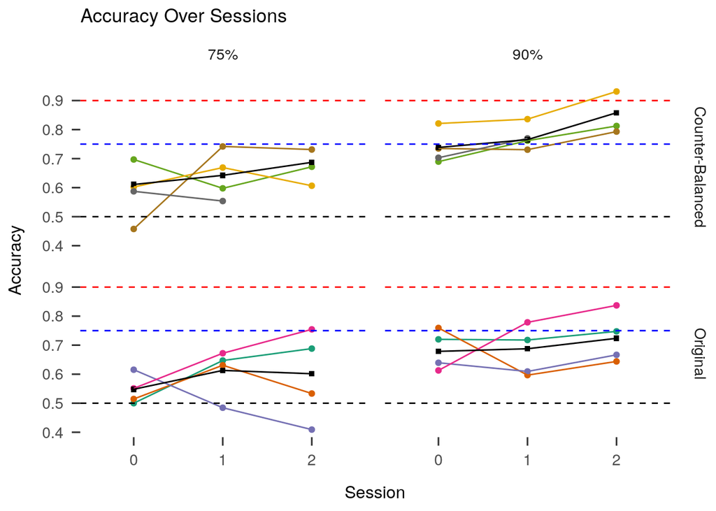

```r
# Figure 3
dat %>%
  ggplot(aes(x=as.factor(session),y=isCorrect,color=as.factor(partID)))+
  geom_point(stat = "summary", fun.y="mean")+
  geom_point(aes(group=1),stat = "summary", fun.y="mean", shape=15)+
  geom_line(aes(group=partID),stat = "summary", fun.y="mean")+
  geom_line(aes(group=1),stat = "summary", fun.y="mean")+
  geom_hline(yintercept = 0.5, linetype='dashed')+
  geom_hline(yintercept = 0.75, linetype= 'dashed', color='blue')+
  geom_hline(yintercept = 0.90, linetype= 'dashed', color='red')+
  scale_y_continuous(breaks = scales::pretty_breaks(n = 5))+
  scale_color_brewer(palette="Dark2")+
  theme_apa()+
  theme(legend.position = "none")+
  facet_grid(version2~probCond2)+
  labs(title = "Accuracy Over Sessions",
     x = "Session",
     y = "Accuracy")
```

```r
# Blue line: 75% mark for low probability condition
# Red line: 90% mark for high probability condition
```

```r
mod1 <- lmer(data=dat[dat$respSuccess==1],
             isCorrect ~ probCond2*contCondName+version+session+
               (probCond2+contCondName|partID:session),
             control = lmerControl(optimizer = 'optimx', optCtrl=list(method='bobyqa')))

# f-statistics output of the model
anova(mod1)
```

|  | Sum Sq | Mean Sq | NumDF | DenDF | F value | Pr(>F) |
| --- | --- | --- | --- | --- | --- | --- |
| probCond2 | 9.44145052 | 9.44145052 | 1 | 21.67792 | 45.617908 | 9.387553e-07 |
| contCondName | 0.29142243 | 0.29142243 | 1 | 22.02662 | 1.408055 | 2.480209e-01 |
| version | 2.07264368 | 2.07264368 | 1 | 20.80183 | 10.014316 | 4.710390e-03 |
| session | 1.11554868 | 1.11554868 | 1 | 20.91694 | 5.389955 | 3.043389e-02 |
| probCond2:contCondName | 0.03408991 | 0.03408991 | 1 | 3345.78291 | 0.164711 | 6.848817e-01 |

```r
# beta estimates, standard errors and CI (95%)
sjstats::std_beta(mod1)
```

| term | std.estimate | std.error | conf.low | conf.high |
| --- | --- | --- | --- | --- |
| probCond290% | 0.14479514 | 0.02546708 | 0.094880589 | 0.19470969 |
| contCondNameShape | 0.03319472 | 0.02814131 | -0.021961241 | 0.08835068 |
| version | 0.08419360 | 0.02660532 | 0.032048138 | 0.13633907 |
| session | 0.06186461 | 0.02664708 | 0.009637285 | 0.11409194 |
| probCond290%:contCondNameShape | -0.01102640 | 0.02716891 | -0.064276489 | 0.04222370 |

### Reliability Vs Absolute Confidence Rating

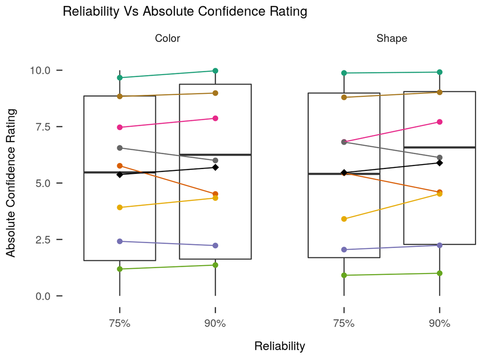

```r
# Figure 4
dat[dat$respSuccess==1] %>%
  ggplot(aes(x=as.factor(probCond2),y=absConfRating,color=as.factor(partID)))+
  geom_boxplot(aes(group=probCond2))+
  geom_point(aes(group=partID),stat = "summary", fun.y="mean", size=2)+
  geom_line(aes(group=partID),stat = "summary", fun.y="mean")+
  geom_point(aes(group=1),stat = "summary", fun.y="mean", size=3, shape=18)+
  geom_line(aes(group=1),stat = "summary", fun.y="mean")+
  scale_color_brewer(palette="Dark2")+
  theme_apa()+
  theme(legend.position = "none")+
  facet_grid(~contCondName)+
  labs(title = "Reliability Vs Absolute Confidence Rating",
       x = "Reliability",
       y = "Absolute Confidence Rating")
```

```r
mod2 <- lmer(data=dat[dat$respSuccess==1],
             absConfRating~probCond2*
               contCondName+
               session+
               version+
               (contCondName+probCond2|partID:session),
             control = lmerControl(optimizer = 'optimx', optCtrl=list(method='bobyqa')))

# f-statistics output of the model
anova(mod2)
```

|  | Sum Sq | Mean Sq | NumDF | DenDF | F value | Pr(>F) |
| --- | --- | --- | --- | --- | --- | --- |
| probCond2 | 2.30290023 | 2.30290023 | 1 | 21.83048 | 0.666752269 | 0.42300769 |
| contCondName | 18.22008626 | 18.22008626 | 1 | 21.93460 | 5.275210665 | 0.03155326 |
| session | 0.02527081 | 0.02527081 | 1 | 20.02677 | 0.007316586 | 0.93268382 |
| version | 4.96778358 | 4.96778358 | 1 | 20.00426 | 1.438308499 | 0.24442648 |
| probCond2:contCondName | 13.71450737 | 13.71450737 | 1 | 2212.50902 | 3.970722998 | 0.04642055 |

```r
# beta estimates, standard errors and CI (95%)
sjstats::std_beta(mod2)
```

| term | std.estimate | std.error | conf.low | conf.high |
| --- | --- | --- | --- | --- |
| probCond290% | 0.002729939 | 0.02403154 | -0.0443710156 | 0.04983089 |
| contCondNameShape | -0.038175248 | 0.01299484 | -0.0636446729 | -0.01270582 |
| session | 0.014849854 | 0.17360729 | -0.3254141780 | 0.35511389 |
| version | -0.208177540 | 0.17358326 | -0.5483944834 | 0.13203940 |
| probCond290%:contCondNameShape | 0.028279098 | 0.01419158 | 0.0004641118 | 0.05609408 |

### Prediction Error Vs Confidence Change

The “confWillChange” variable was derived by subtracting the current *ith* row’s confidence rating (“confRatingCorr”) by the proceeding *i+1th* row’s confidence rating.
$$ConfWillChange_i = (ConfRating_i - ConfRating_{i+1})\times-1$$
It represents the change in confidence that will occur after ith trial. This was derived using the following code:

```r
dat[,("confWillChange") := ifelse(trialSess != 191,(confRatingCorr - shift(dat$confRatingCorr, type = "lead"))*-1, NA)]
```

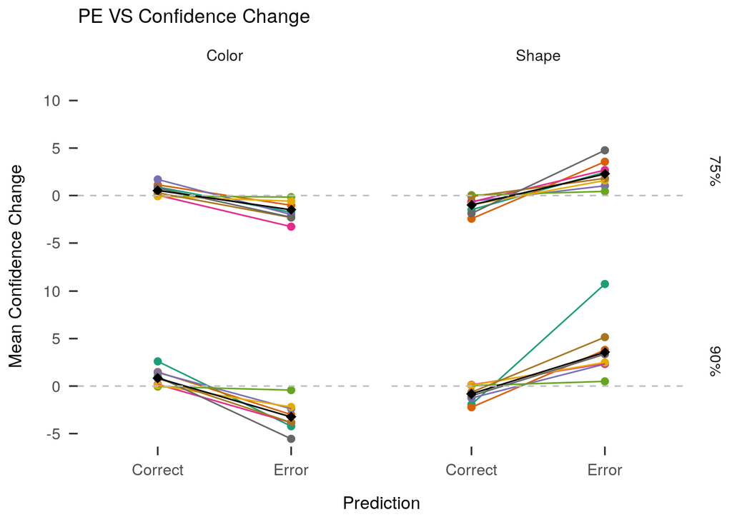

```r
# Figure 5
dat[dat$respSuccess==1] %>%
  ggplot(aes(x=as.factor(isError2),y=confWillChange,color=as.factor(partID)))+
  geom_point(aes(group=partID),stat = "summary", fun.y="mean", size=2)+
  geom_line(aes(group=partID),stat = "summary", fun.y="mean")+
  geom_point(aes(group=1),stat = "summary", fun.y="mean", size=3, shape=18)+
  geom_line(aes(group=1),stat = "summary", fun.y="mean")+
  geom_hline(yintercept = 0, color='grey', linetype='dashed')+
  scale_color_brewer(palette="Dark2")+
  theme_apa()+
  facet_grid(probCond2~contCondName)+
  theme(legend.position = "none")+
  labs(title = "PE VS Confidence Change",
       x = "Prediction",
       y = "Mean Confidence Change")
```

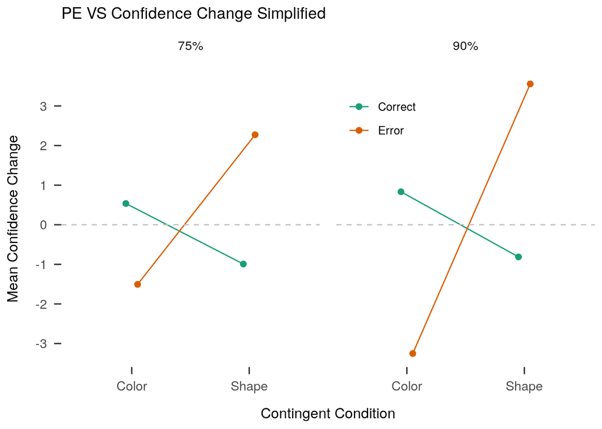

```r
# Figure 6
dat[dat$respSuccess==1] %>%
  ggplot(aes(x=as.factor(contCondName),y=confWillChange,color=as.factor(isError2)))+
  geom_point(aes(group=isError2),stat = "summary", fun.y="mean", size=2, position = position_dodge(width = 0.2))+
  geom_line(aes(group=isError2),stat = "summary", fun.y="mean",position = position_dodge(width = 0.2))+
  scale_color_brewer(palette="Dark2")+
  geom_hline(yintercept = 0, color='grey', linetype='dashed')+
  theme(legend.title=element_blank())+
  theme_apa()+
  facet_grid(~probCond2)+
  theme(legend.title=element_blank())+
  labs(title = "PE VS Confidence Change Simplified",
       x = "Contingent Condition",
       y = "Mean Confidence Change")+
  scale_y_continuous(breaks = seq(-15, 15))+
  theme(legend.position = c(0.6,0.85))
```

```r
mod3<-dat[dat$respSuccess==1] %>%
  dplyr::group_by(partID,version,session,probCond2,contCondName, isError2) %>%
  summarise(confWillChange = mean(confWillChange, na.rm=T)) %>%
  lm(data=. ,
     confWillChange~factor(isError2)*
       factor(probCond2)*
       factor(contCondName)+
       session+
       factor(version))

# f-statistics output of the model
car::Anova(mod3, type=3)
```

|  | Sum Sq | Df | F value | Pr(>F) |
| --- | --- | --- | --- | --- |
| (Intercept) | 2.9547258 | 1 | 0.6048525 | 4.377887e-01 |
| factor(isError2) | 45.8719081 | 1 | 9.3902926 | 2.528930e-03 |
| factor(probCond2) | 2.3317009 | 1 | 0.4773151 | 4.905616e-01 |
| factor(contCondName) | 29.7965046 | 1 | 6.0995478 | 1.448608e-02 |
| session | 7.5993874 | 1 | 1.5556465 | 2.139800e-01 |
| factor(version) | 0.8665274 | 1 | 0.1773841 | 6.741508e-01 |
| factor(isError2):factor(probCond2) | 29.3783709 | 1 | 6.0139530 | 1.518013e-02 |
| factor(isError2):factor(contCondName) | 154.0828221 | 1 | 31.5418052 | 7.600229e-08 |
| factor(probCond2):factor(contCondName) | 1.0342545 | 1 | 0.2117190 | 6.459979e-01 |
| factor(isError2):factor(probCond2):factor(contCondName) | 60.1000910 | 1 | 12.3028988 | 5.755276e-04 |

[output cut: 1 more lines]

```r
# beta estimates, standard errors and CI (95%)
sjstats::std_beta(mod3)
```

| term | std.estimate | std.error | conf.low | conf.high |
| --- | --- | --- | --- | --- |
| factor(isError2)Error | -0.32046952 | 0.10457964 | -0.52544185 | -0.11549718 |
| factor(probCond2)90% | 0.07225198 | 0.10457964 | -0.13272036 | 0.27722431 |
| factor(contCondName)Shape | -0.25828310 | 0.10457964 | -0.46325543 | -0.05331076 |
| session | 0.06532243 | 0.05237293 | -0.03732663 | 0.16797149 |
| factor(version)1 | -0.02205790 | 0.05237293 | -0.12470696 | 0.08059116 |
| factor(isError2)Error:factor(probCond2)90% | -0.31410352 | 0.12808338 | -0.56514234 | -0.06306470 |
| factor(isError2)Error:factor(contCondName)Shape | 0.71934307 | 0.12808338 | 0.46830425 | 0.97038189 |
| factor(probCond2)90%:factor(contCondName)Shape | -0.05893492 | 0.12808338 | -0.30997373 | 0.19210390 |
| factor(isError2)Error:factor(probCond2)90%:factor(contCondName)Shape | 0.48525488 | 0.13834587 | 0.21410197 | 0.75640779 |

### Surprise Type Vs Confidence Change

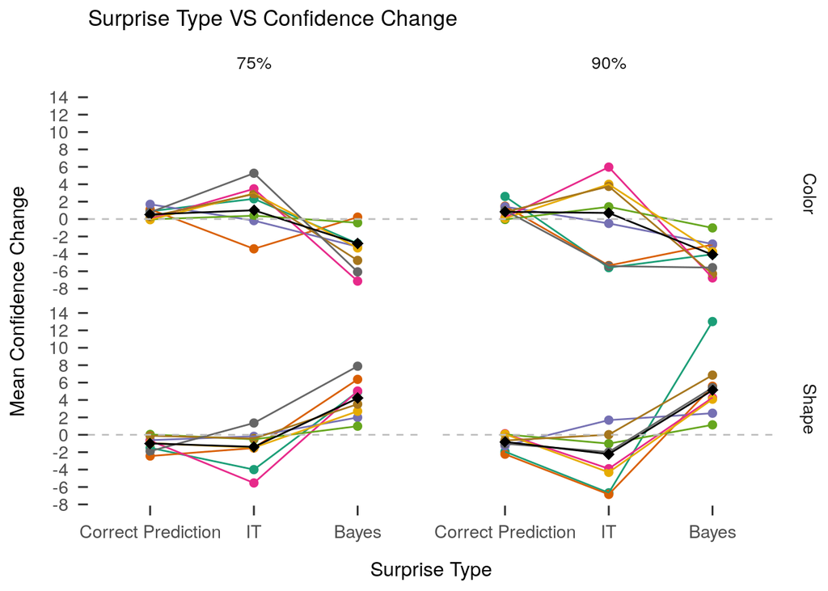

```r
# Figure 7
dat[dat$respSuccess==1] %>%
  ggplot(aes(x=factor(surpriseType2,
                      levels = c('Correct Prediction', 'IT', 'Bayes')),
             y=confWillChange,color=as.factor(partID)))+
  geom_point(aes(group=partID),stat = "summary", fun.y="mean", size=2)+
  geom_line(aes(group=partID),stat = "summary", fun.y="mean")+
  geom_point(aes(group=1),stat = "summary", fun.y="mean", size=3, shape=18)+
  geom_line(aes(group=1),stat = "summary", fun.y="mean")+
  geom_hline(yintercept = 0, color='grey', linetype='dashed')+
  scale_color_brewer(palette="Dark2")+
  theme_apa()+
  facet_grid(contCondName~probCond2)+
  theme(legend.position = "none")+
  labs(title = "Surprise Type VS Confidence Change",
       x = "Surprise Type",
       y = "Mean Confidence Change")+
  scale_y_continuous(breaks = scales::pretty_breaks(n = 10))
```

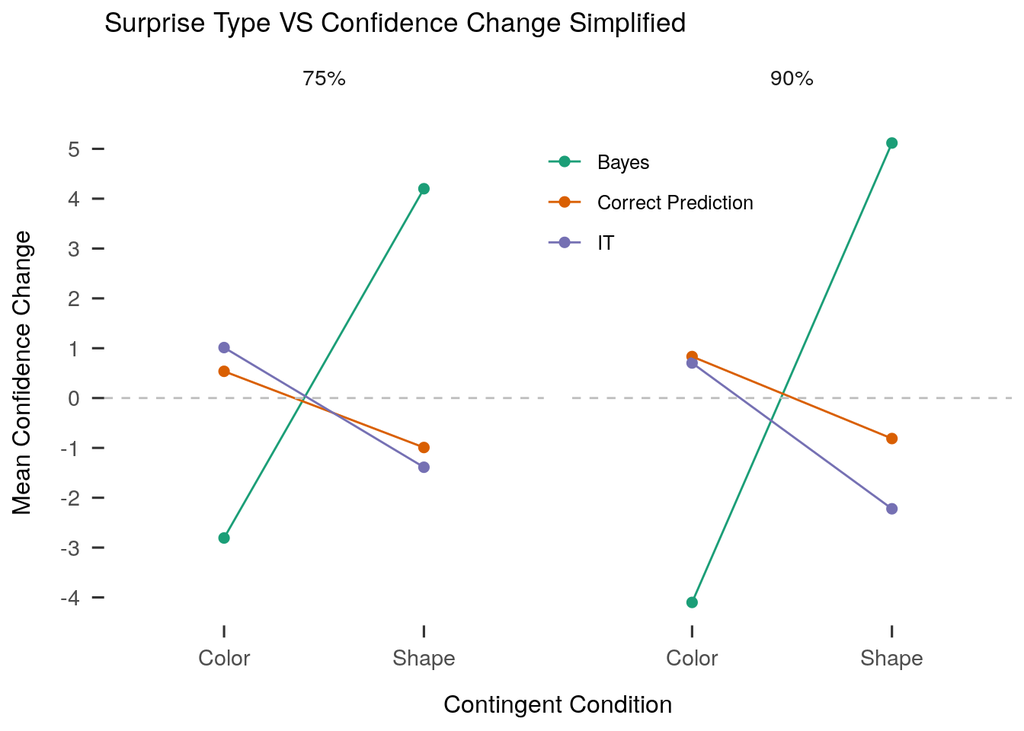

```r
# Figure 8
dat[dat$respSuccess==1] %>%
  ggplot(aes(x=as.factor(contCondName),y=confWillChange,color=as.factor(surpriseType2)))+
  geom_point(aes(group=surpriseType2),stat = "summary", fun.y="mean", size=2)+
  geom_line(aes(group=surpriseType2),stat = "summary", fun.y="mean")+
  geom_hline(yintercept = 0, color='grey', linetype='dashed')+
  scale_color_brewer(palette="Dark2")+
  theme_apa()+
  facet_grid(~probCond2)+
  theme(legend.title=element_blank())+
  labs(title = "Surprise Type VS Confidence Change Simplified",
       x = "Contingent Condition",
       y = "Mean Confidence Change")+
  scale_y_continuous(breaks = scales::pretty_breaks(n = 10))+
  theme(legend.position = c(0.6,0.85))
```

```r
mod4<-dat[dat$respSuccess==1] %>%
  dplyr::group_by(partID,version,session,probCond2,contCondName,surpriseType2) %>%
  summarise(confWillChange = mean(confWillChange, na.rm=T)) %>%
  lm(data=. ,
     confWillChange~factor(surpriseType2)*
       factor(probCond2)*
       factor(contCondName)+
       session+
       factor(version))

# f-statistics output of the model
car::Anova(mod4, type=3)
```

|  | Sum Sq | Df | F value | Pr(>F) |
| --- | --- | --- | --- | --- |
| (Intercept) | 305.98543 | 1 | 18.2928609 | 2.680257e-05 |
| factor(surpriseType2) | 356.78993 | 2 | 10.6650642 | 3.562645e-05 |
| factor(probCond2) | 17.75560 | 1 | 1.0614907 | 3.038517e-01 |
| factor(contCondName) | 622.68180 | 1 | 37.2260585 | 3.885912e-09 |
| session | 49.95020 | 1 | 2.9861947 | 8.518790e-02 |
| factor(version) | 16.23597 | 1 | 0.9706422 | 3.254539e-01 |
| factor(surpriseType2):factor(probCond2) | 35.12304 | 2 | 1.0498881 | 3.514847e-01 |
| factor(surpriseType2):factor(contCondName) | 828.30278 | 2 | 24.7593936 | 1.489623e-10 |
| factor(probCond2):factor(contCondName) | 54.27929 | 1 | 3.2450027 | 7.282281e-02 |
| factor(surpriseType2):factor(probCond2):factor(contCondName) | 38.89814 | 2 | 1.1627324 | 3.142826e-01 |

[output cut: 1 more lines]

```r
# beta estimates, standard errors and CI (95%)
sjstats::std_beta(mod4)
```

| term | std.estimate | std.error | conf.low | conf.high |
| --- | --- | --- | --- | --- |
| factor(surpriseType2)Correct Prediction | 0.37095466 | 0.11594557 | 0.14370552 | 0.59820380 |
| factor(surpriseType2)IT | 0.50954164 | 0.11362973 | 0.28683146 | 0.73225183 |
| factor(probCond2)90% | -0.12586556 | 0.12216556 | -0.36530566 | 0.11357455 |
| factor(contCondName)Shape | 0.74561807 | 0.12220610 | 0.50609851 | 0.98513763 |
| session | 0.08763726 | 0.05071422 | -0.01176078 | 0.18703530 |
| factor(version)1 | 0.04996127 | 0.05071120 | -0.04943086 | 0.14935341 |
| factor(surpriseType2)Correct Prediction:factor(probCond2)90% | 0.12917026 | 0.13014274 | -0.12590483 | 0.38424535 |
| factor(surpriseType2)IT:factor(probCond2)90% | -0.05471642 | 0.12486021 | -0.29943793 | 0.19000509 |
| factor(surpriseType2)Correct Prediction:factor(contCondName)Shape | -0.68429504 | 0.13014274 | -0.93937013 | -0.42921994 |
| factor(surpriseType2)IT:factor(contCondName)Shape | -0.84605934 | 0.12667096 | -1.09432986 | -0.59778882 |

[output cut: 3 more lines]

### Reaction Time Vs Sessions

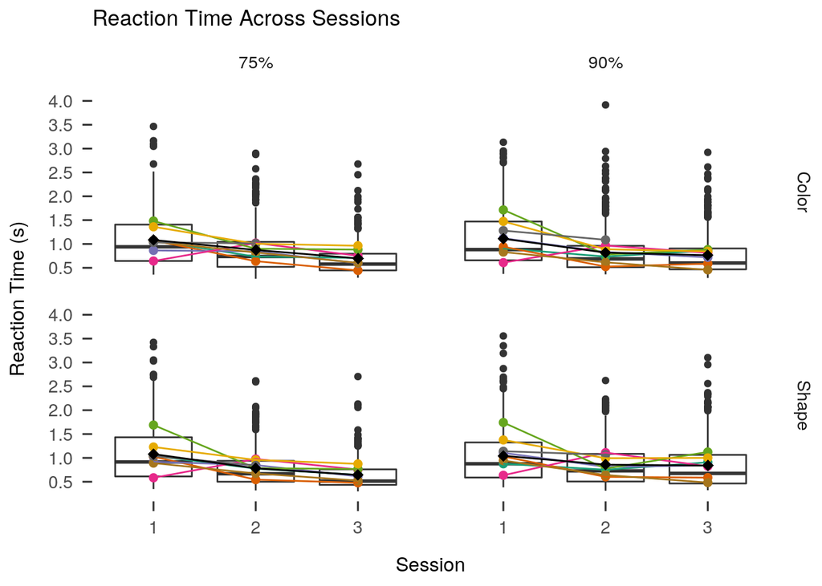

```r
# Figure 9
dat[dat$respSuccess==1] %>%
  mutate(session = session+1) %>%
  ggplot(aes(x=as.factor(session),y=firstRT,color=as.factor(partID)))+
  geom_boxplot(aes(group=session))+
  geom_point(aes(group=partID),stat = "summary", fun.y="mean", size=2)+
  geom_line(aes(group=partID),stat = "summary", fun.y="mean")+
  geom_point(aes(group=1),stat = "summary", fun.y="mean", size=3, shape=18)+
  geom_line(aes(group=1),stat = "summary", fun.y="mean")+
  scale_color_brewer(palette="Dark2")+
  theme_apa()+
  facet_grid(contCondName~probCond2)+
  theme(legend.position = "none")+
  labs(title = "Reaction Time Across Sessions",
       x = "Session",
       y = "Reaction Time (s)")+
  scale_y_continuous(breaks = scales::pretty_breaks(n = 10))
```

```r
mod5 <- lmer(data=dat[dat$respSuccess==1],
             firstRT ~ probCond2*
               contCondName+
               session+
               version+
               (probCond2|partID:session))

# f-statistics output of the model
anova(mod5)
```

|  | Sum Sq | Mean Sq | NumDF | DenDF | F value | Pr(>F) |
| --- | --- | --- | --- | --- | --- | --- |
| probCond2 | 0.51745503 | 0.51745503 | 1 | 22.22543 | 2.60284161 | 0.1207822218 |
| contCondName | 0.00322863 | 0.00322863 | 1 | 4375.33101 | 0.01624028 | 0.8986001205 |
| session | 3.44290468 | 3.44290468 | 1 | 20.52577 | 17.31809544 | 0.0004600919 |
| version | 1.31336604 | 1.31336604 | 1 | 20.58613 | 6.60633985 | 0.0180079853 |
| probCond2:contCondName | 1.61862126 | 1.61862126 | 1 | 4381.08966 | 8.14179889 | 0.0043459222 |

```r
# beta estimates, standard errors and CI (95%)
sjstats::std_beta(mod5)
```

| term | std.estimate | std.error | conf.low | conf.high |
| --- | --- | --- | --- | --- |
| probCond290% | 0.0008015853 | 0.02714822 | -0.05240796 | 0.054011126 |
| contCondNameShape | -0.0360412287 | 0.01950463 | -0.07426960 | 0.002187145 |
| session | -0.3003751474 | 0.07217951 | -0.44184439 | -0.158905906 |
| version | 0.1857033691 | 0.07225025 | 0.04409549 | 0.327311248 |
| probCond290%:contCondNameShape | 0.0671903625 | 0.02354761 | 0.02103790 | 0.113342826 |

## Pupil Data Analysis

When analyzing pupil data, we had to derive summary data for each trial from the time-series pupil data. This involved extracting the maximum pupil diameter and its time stamp from each trial’s feedback section, and extracting the baseline pupil diameter from each trial’s fixation section before the feedback onset.  
Next, we computed whether a trial was blinkSafe where no more than 50% of both the fixation section and feedback section was occupied by blinks.  
This was accomplished using the following codes:

```r
# example data table without key data.
dat2 <- dat %>% dplyr::select(-c(peakPupil, peakTime, isBlinkSafe, baseline))

# Find peak puil and its timestamp
tempDat1 <- datPupil[datPupil$section==4][,. (peakPupil = max(pupilAvg), peakTime = secTimestamp[pupilAvg==max(pupilAvg)]), by=.(partID,trialTotal)]

# compute blink safety
tempDat2<-eyeDat[eyeDat$section>=3][,. (isBlinkSafe = ifelse(mean(isBlink[section == 3]) >= 0.5 | mean(isBlink[section==4]) > 0.5,F,T)), by=.(partID,trialTotal)]

# compute baseline
tempDat3<-eyeDat[eyeDat$section==3][,. (baseline = mean(pupilAvg[secTimestamp>=(max(secTimestamp)-100)])), by=.(partID,trialTotal)]

  # merge with the summary data
dat2 <- merge(dat2,tempDat1, by=c("partID","trialTotal"),all.x=T)
dat2 <- merge(dat2,tempDat2, by=c("partID","trialTotal"),all.x=T)
dat2 <- merge(dat2,tempDat3, by=c("partID","trialTotal"),all.x=T)
```

With the pupil data extracted from the pupil data table, we can compute data such as the baseline corrected peak pupil diameter and exclude trials where there were too many blinks.

### Prediction Vs Peak Pupil Dilation Size

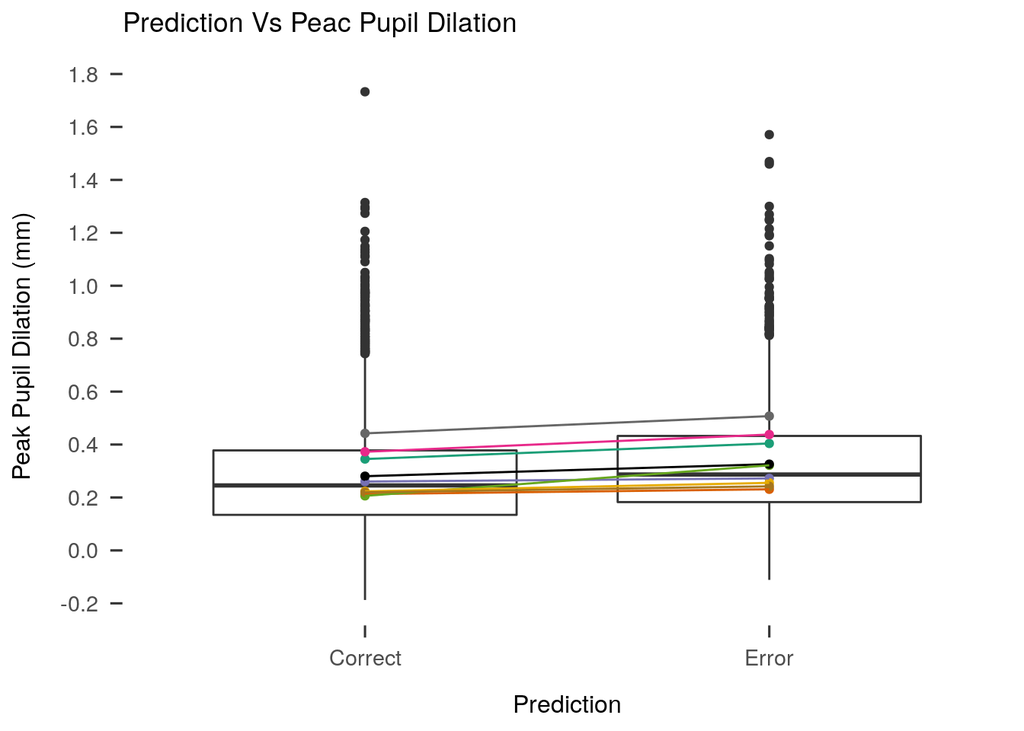

```r
# Figure 10
dat[dat$isBlinkSafe==T] %>%
  ggplot(aes(x=as.factor(isError2),y=baseCorPeakPupil,color=as.factor(partID)))+
  geom_boxplot(aes(group=isError2))+
  geom_point(stat = "summary", fun.y="mean")+
  geom_point(aes(group=isError2),stat = "summary", fun.y="mean")+
  geom_line(aes(group=1),stat = "summary", fun.y="mean")+
  geom_line(aes(group=partID),stat = "summary", fun.y="mean")+
  theme_apa()+
  scale_color_brewer(palette="Dark2")+
  theme(legend.position = "none")+
  scale_y_continuous(breaks = scales::pretty_breaks(n = 10))+
  labs(title = "Prediction Vs Peac Pupil Dilation",
       x = "Prediction",
       y = "Peak Pupil Dilation (mm)")
```

```r
mod6<- lmer(data=dat[dat$isBlinkSafe==T],
              baseCorPeakPupil~isError2*
              probCond2*
              contCondName+
              baseline+
              peakTimeSec+
              session+
              version+
              (isError2+probCond+contCondName+baseline|partID:session),
            control = lmerControl(optimizer = 'optimx', optCtrl=list(method='bobyqa')))

# f-statistics output of the model
anova(mod6)
```

|  | Sum Sq | Mean Sq | NumDF | DenDF | F value | Pr(>F) |
| --- | --- | --- | --- | --- | --- | --- |
| isError2 | 0.888885697 | 0.888885697 | 1 | 21.32665 | 3.425913e+01 | 7.765055e-06 |
| probCond2 | 0.014138951 | 0.014138951 | 1 | 24.17409 | 5.449387e-01 | 4.674997e-01 |
| contCondName | 0.028604803 | 0.028604803 | 1 | 28.33690 | 1.102477e+00 | 3.025960e-01 |
| baseline | 2.181155742 | 2.181155742 | 1 | 22.05642 | 8.406536e+01 | 5.584834e-09 |
| peakTimeSec | 21.605155109 | 21.605155109 | 1 | 4179.88022 | 8.326986e+02 | 3.888771e-167 |
| session | 0.019246114 | 0.019246114 | 1 | 19.36356 | 7.417772e-01 | 3.996320e-01 |
| version | 0.222942438 | 0.222942438 | 1 | 19.08585 | 8.592572e+00 | 8.539430e-03 |
| isError2:probCond2 | 0.062894080 | 0.062894080 | 1 | 3239.58488 | 2.424042e+00 | 1.195839e-01 |
| isError2:contCondName | 0.000176875 | 0.000176875 | 1 | 3976.46976 | 6.817055e-03 | 9.342012e-01 |
| probCond2:contCondName | 0.004642617 | 0.004642617 | 1 | 2345.62978 | 1.789342e-01 | 6.723296e-01 |

[output cut: 1 more lines]

```r
# beta estimates, standard errors and CI (95%)
sjstats::std_beta(mod6)
```

| term | std.estimate | std.error | conf.low | conf.high |
| --- | --- | --- | --- | --- |
| isError2Error | 0.112323969 | 0.02936116 | 0.05477716 | 0.16987078 |
| probCond290% | -0.004085616 | 0.02725255 | -0.05749963 | 0.04932840 |
| contCondNameShape | -0.015864879 | 0.02228249 | -0.05953777 | 0.02780801 |
| baseline | -0.664694693 | 0.07249594 | -0.80678412 | -0.52260527 |
| peakTimeSec | 0.376520229 | 0.01304801 | 0.35094659 | 0.40209387 |
| session | -0.125301160 | 0.14548504 | -0.41044661 | 0.15984429 |
| version | -0.424926682 | 0.14496141 | -0.70904583 | -0.14080753 |
| isError2Error:probCond290% | 0.021212513 | 0.02453996 | -0.02688492 | 0.06930994 |
| isError2Error:contCondNameShape | -0.005199036 | 0.02502638 | -0.05424985 | 0.04385178 |
| probCond290%:contCondNameShape | 0.001139646 | 0.02522879 | -0.04830787 | 0.05058717 |

[output cut: 1 more lines]

### Prediction Vs Peak Pupil Dilation Latency

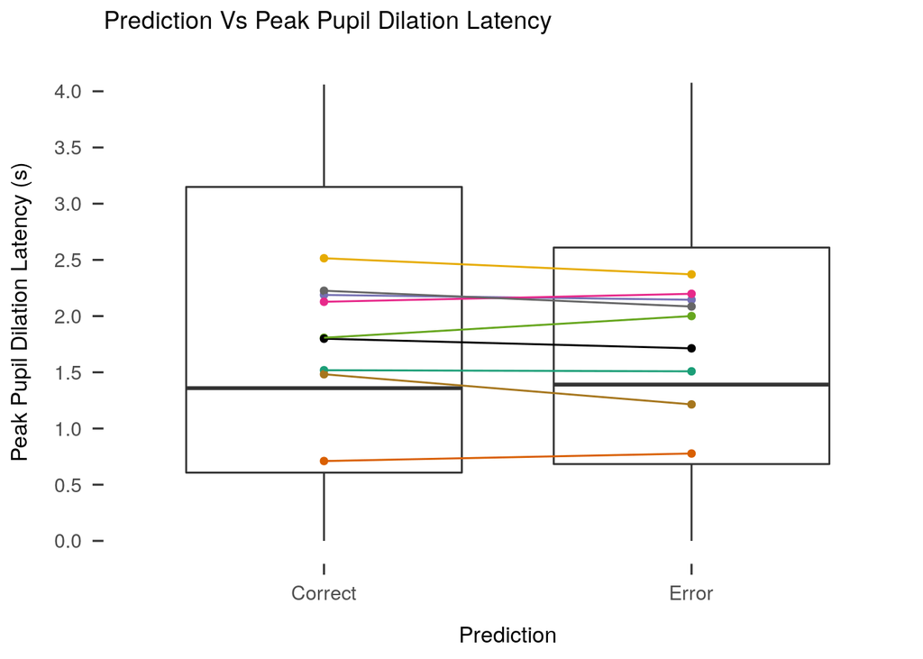

```r
# Figure 11
dat[dat$isBlinkSafe==T] %>%
  ggplot(aes(x=as.factor(isError2),y=peakTimeSec,color=as.factor(partID)))+
  geom_boxplot(aes(group=isError2))+
  geom_point(stat = "summary", fun.y="mean")+
  geom_point(aes(group=isError2),stat = "summary", fun.y="mean")+
  geom_line(aes(group=1),stat = "summary", fun.y="mean")+
  geom_line(aes(group=partID),stat = "summary", fun.y="mean")+
  theme_apa()+
  scale_color_brewer(palette="Dark2")+
  theme(legend.position = "none")+
  scale_y_continuous(breaks = scales::pretty_breaks(n = 10))+
  labs(title = "Prediction Vs Peak Pupil Dilation Latency",
       x = "Prediction",
       y = "Peak Pupil Dilation Latency (s)")
```

```r
mod7 <- lmer(data=dat[dat$isBlinkSafe==T],
             peakTimeSec~isError2*
               probCond2*
               contCondName+
               baseCorPeakPupil+
               baseline+
               session+
               version+
               (isError2+baseline+baseCorPeakPupil|partID:session),
             control = lmerControl(optimizer = 'optimx', optCtrl=list(method='bobyqa')))

# f-statistics output of the model
anova(mod7)
```

|  | Sum Sq | Mean Sq | NumDF | DenDF | F value | Pr(>F) |
| --- | --- | --- | --- | --- | --- | --- |
| isError2 | 1.295611e+01 | 1.295611e+01 | 1 | 22.35379 | 1.229168e+01 | 1.960484e-03 |
| probCond2 | 2.969772e+00 | 2.969772e+00 | 1 | 4063.56904 | 2.817471e+00 | 9.332008e-02 |
| contCondName | 4.773937e-01 | 4.773937e-01 | 1 | 4162.65513 | 4.529113e-01 | 5.009930e-01 |
| baseCorPeakPupil | 1.427327e+02 | 1.427327e+02 | 1 | 18.98522 | 1.354129e+02 | 4.387557e-10 |
| baseline | 2.400773e+00 | 2.400773e+00 | 1 | 18.08985 | 2.277653e+00 | 1.485187e-01 |
| session | 3.290395e-02 | 3.290395e-02 | 1 | 12.03642 | 3.121652e-02 | 8.626963e-01 |
| version | 4.979112e-03 | 4.979112e-03 | 1 | 11.73031 | 4.723765e-03 | 9.463625e-01 |
| isError2:probCond2 | 2.476114e-01 | 2.476114e-01 | 1 | 3211.30917 | 2.349130e-01 | 6.279376e-01 |
| isError2:contCondName | 1.041232e+00 | 1.041232e+00 | 1 | 4157.98633 | 9.878338e-01 | 3.203302e-01 |
| probCond2:contCondName | 1.006011e+00 | 1.006011e+00 | 1 | 4138.92013 | 9.544189e-01 | 3.286541e-01 |

[output cut: 1 more lines]

```r
# beta estimates, standard errors and CI (95%)
sjstats::std_beta(mod7)
```

| term | std.estimate | std.error | conf.low | conf.high |
| --- | --- | --- | --- | --- |
| isError2Error | -0.076504284 | 0.02807191 | -0.13152422 | -0.02148435 |
| probCond290% | -0.008751902 | 0.02197522 | -0.05182254 | 0.03431873 |
| contCondNameShape | -0.014130021 | 0.02314946 | -0.05950213 | 0.03124209 |
| baseCorPeakPupil | 0.467474906 | 0.04017245 | 0.38873836 | 0.54621145 |
| baseline | -0.073531351 | 0.04872242 | -0.16902553 | 0.02196283 |
| session | -0.010008296 | 0.05664582 | -0.12103206 | 0.10101547 |
| version | 0.003878978 | 0.05643820 | -0.10673786 | 0.11449582 |
| isError2Error:probCond290% | -0.002252953 | 0.02615451 | -0.05351486 | 0.04900895 |
| isError2Error:contCondNameShape | 0.026059670 | 0.02674648 | -0.02636247 | 0.07848181 |
| probCond290%:contCondNameShape | -0.014360859 | 0.02689837 | -0.06708070 | 0.03835898 |

[output cut: 1 more lines]

### Surprise Type Vs Peak Pupil Dilation Size

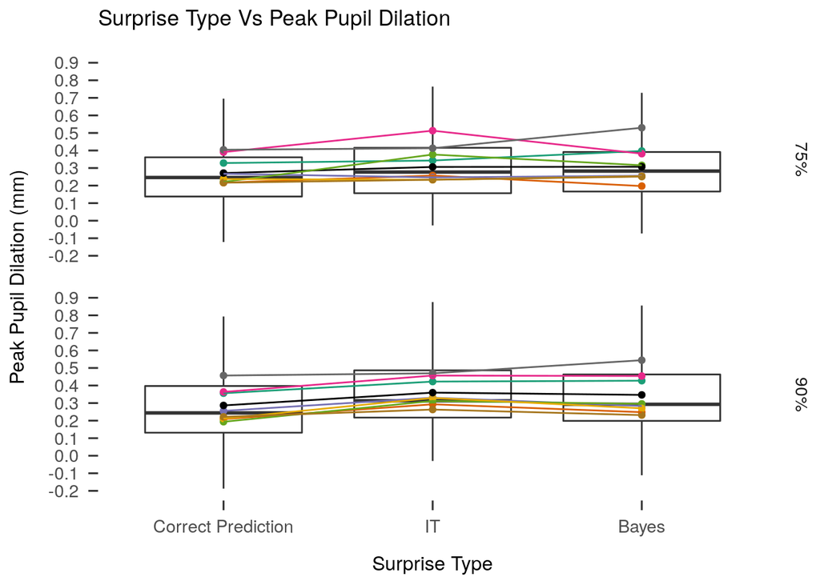

```r
# Figure 12
dat[dat$isBlinkSafe==T] %>%
  ggplot(aes(x=reorder(as.factor(surpriseType2),+baseCorPeakPupil),
             y=baseCorPeakPupil,color=as.factor(partID)))+
  geom_boxplot(aes(group=surpriseType2), outlier.size = -1)+
  geom_point(stat = "summary", fun.y="mean")+
  geom_point(aes(group=surpriseType),stat = "summary", fun.y="mean")+
  geom_line(aes(group=1),stat = "summary", fun.y="mean")+
  geom_line(aes(group=partID),stat = "summary", fun.y="mean")+
  theme_apa()+
  scale_color_brewer(palette="Dark2")+
  theme(legend.position = "none")+
  scale_y_continuous(breaks = scales::pretty_breaks(n = 10))+
  labs(title = "Surprise Type Vs Peak Pupil Dilation",
       x = "Surprise Type",
       y = "Peak Pupil Dilation (mm)")+
  facet_grid(probCond2~.)+
  coord_cartesian(ylim = c(-0.2, 0.9))
```

```r
mod8 <- lmer(data=dat[dat$isBlinkSafe==T],
             baseCorPeakPupil~factor(surpriseType)*
               probCond2*
               contCondName+
               baseline+
               peakTimeSec+
               session+
               version+
               (probCond2+contCondName+baseline+peakTimeSec|partID:session),
             control = lmerControl(optimizer = 'optimx', optCtrl=list(method='bobyqa')))

# f-statistics output of the model
anova(mod8)
```

|  | Sum Sq | Mean Sq | NumDF | DenDF | F value | Pr(>F) |
| --- | --- | --- | --- | --- | --- | --- |
| factor(surpriseType) | 2.751355371 | 1.375677685 | 2 | 4132.66190 | 54.0765278 | 6.560102e-24 |
| probCond2 | 0.030669309 | 0.030669309 | 1 | 39.07501 | 1.2055802 | 2.789292e-01 |
| contCondName | 0.005001489 | 0.005001489 | 1 | 68.78615 | 0.1966036 | 6.588680e-01 |
| baseline | 2.014973952 | 2.014973952 | 1 | 21.43170 | 79.2066311 | 1.203787e-08 |
| peakTimeSec | 2.351225064 | 2.351225064 | 1 | 20.67116 | 92.4243293 | 4.468425e-09 |
| session | 0.003887702 | 0.003887702 | 1 | 18.97101 | 0.1528217 | 7.002088e-01 |
| version | 0.061983457 | 0.061983457 | 1 | 18.92824 | 2.4365083 | 1.351039e-01 |
| factor(surpriseType):probCond2 | 0.134263056 | 0.067131528 | 2 | 4152.28424 | 2.6388739 | 7.156149e-02 |
| factor(surpriseType):contCondName | 0.047944231 | 0.023972115 | 2 | 4092.87731 | 0.9423201 | 3.898071e-01 |
| probCond2:contCondName | 0.015164756 | 0.015164756 | 1 | 3343.85359 | 0.5961116 | 4.401201e-01 |

[output cut: 1 more lines]

```r
# beta estimates, standard errors and CI (95%)
sjstats::std_beta(mod8)
```

| term | std.estimate | std.error | conf.low | conf.high |
| --- | --- | --- | --- | --- |
| factor(surpriseType)0 | 0.0552127315 | 0.02015135 | 0.01571681 | 0.09470865 |
| factor(surpriseType)1 | 0.1050734489 | 0.02334070 | 0.05932651 | 0.15082039 |
| probCond290% | -0.0048062556 | 0.02606985 | -0.05590223 | 0.04628972 |
| contCondNameShape | -0.0111499037 | 0.02240833 | -0.05506943 | 0.03276962 |
| baseline | -0.7028694146 | 0.07897577 | -0.85765908 | -0.54807975 |
| peakTimeSec | 0.3431462297 | 0.03569325 | 0.27318875 | 0.41310371 |
| session | -0.0527577352 | 0.13495644 | -0.31726750 | 0.21175203 |
| version | -0.2104212810 | 0.13480491 | -0.47463405 | 0.05379149 |
| factor(surpriseType)0:probCond290% | 0.0044036530 | 0.02047230 | -0.03572133 | 0.04452863 |
| factor(surpriseType)1:probCond290% | 0.0258245913 | 0.02427066 | -0.02174502 | 0.07339420 |

[output cut: 5 more lines]

### Surprise Type Vs Peak Pupil Dilation Latency

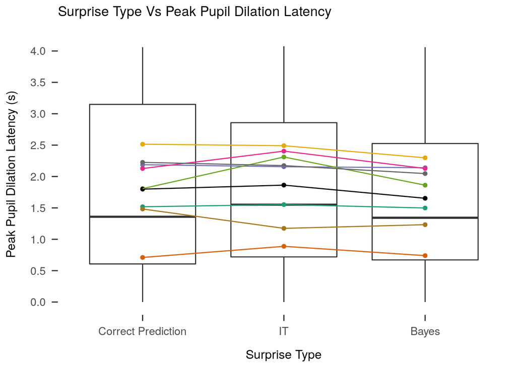

```r
# Figure 13
dat[dat$isBlinkSafe==T] %>%
  ggplot(aes(x=factor(surpriseType2, levels = c('Correct Prediction', 'IT', 'Bayes')),
             y=peakTimeSec,color=as.factor(partID)))+
  geom_boxplot(aes(group=surpriseType2))+
  geom_point(stat = "summary", fun.y="mean")+
  geom_point(aes(group=surpriseType),stat = "summary", fun.y="mean")+
  geom_line(aes(group=1),stat = "summary", fun.y="mean")+
  geom_line(aes(group=partID),stat = "summary", fun.y="mean")+
  theme_apa()+
  scale_color_brewer(palette="Dark2")+
  theme(legend.position = "none")+
  scale_y_continuous(breaks = scales::pretty_breaks(n = 10))+
  labs(title = "Surprise Type Vs Peak Pupil Dilation Latency",
       x = "Surprise Type",
       y = "Peak Pupil Dilation Latency (s)")
```

```r
mod9 <- lmer(data=dat[dat$isBlinkSafe==T],
             peakTimeSec~factor(surpriseType)*
               probCond2*
               contCondName+
               baseline+
               baseCorPeakPupil+
               session+
               version+
               (contCondName+baseline+baseCorPeakPupil|partID:session),
             control = lmerControl(optimizer = 'optimx', optCtrl=list(method='bobyqa')))

# f-statistics output of the model
anova(mod9)
```

|  | Sum Sq | Mean Sq | NumDF | DenDF | F value | Pr(>F) |
| --- | --- | --- | --- | --- | --- | --- |
| factor(surpriseType) | 2.786038e+01 | 1.393019e+01 | 2 | 4174.95250 | 1.313031e+01 | 2.067459e-06 |
| probCond2 | 8.873603e-01 | 8.873603e-01 | 1 | 4136.70258 | 8.364077e-01 | 3.604795e-01 |
| contCondName | 1.116808e-01 | 1.116808e-01 | 1 | 544.79446 | 1.052680e-01 | 7.457216e-01 |
| baseline | 2.603959e+00 | 2.603959e+00 | 1 | 18.11763 | 2.454439e+00 | 1.344923e-01 |
| baseCorPeakPupil | 1.647823e+02 | 1.647823e+02 | 1 | 18.63326 | 1.553205e+02 | 1.756304e-10 |
| session | 1.313582e-03 | 1.313582e-03 | 1 | 12.70753 | 1.238156e-03 | 9.724770e-01 |
| version | 9.914019e-02 | 9.914019e-02 | 1 | 12.40785 | 9.344752e-02 | 7.649073e-01 |
| factor(surpriseType):probCond2 | 2.619321e-01 | 1.309660e-01 | 2 | 4165.19138 | 1.234459e-01 | 8.838727e-01 |
| factor(surpriseType):contCondName | 2.600514e+00 | 1.300257e+00 | 2 | 4161.70345 | 1.225596e+00 | 2.936888e-01 |
| probCond2:contCondName | 5.674503e-01 | 5.674503e-01 | 1 | 4161.73617 | 5.348671e-01 | 4.646090e-01 |

[output cut: 1 more lines]

```r
# beta estimates, standard errors and CI (95%)
sjstats::std_beta(mod9)
```

| term | std.estimate | std.error | conf.low | conf.high |
| --- | --- | --- | --- | --- |
| factor(surpriseType)0 | -0.0219967385 | 0.02180325 | -0.064730326 | 0.02073685 |
| factor(surpriseType)1 | -0.0922848397 | 0.02523508 | -0.141744689 | -0.04282499 |
| probCond290% | -0.0092034256 | 0.02194887 | -0.052222412 | 0.03381556 |
| contCondNameShape | -0.0160820359 | 0.02342799 | -0.062000046 | 0.02983597 |
| baseline | -0.0755172894 | 0.04820258 | -0.169992608 | 0.01895803 |
| baseCorPeakPupil | 0.4647326120 | 0.03728969 | 0.391646160 | 0.53781906 |
| session | 0.0019962751 | 0.05673261 | -0.109197597 | 0.11319015 |
| version | 0.0172980475 | 0.05658655 | -0.093609546 | 0.12820564 |
| factor(surpriseType)0:probCond290% | -0.0008382917 | 0.02216956 | -0.044289835 | 0.04261325 |
| factor(surpriseType)1:probCond290% | 0.0121827818 | 0.02622700 | -0.039221202 | 0.06358677 |

[output cut: 5 more lines]

### Time-series Pupil Diameter

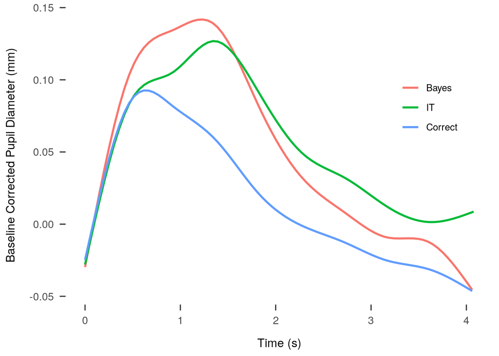

```r
# Figure 14
datPupil %>%
  mutate(secTimestamp = secTimestamp/1000) %>%
  dplyr::filter(section >= 4) %>%
  ggplot(aes(x = secTimestamp,
             y = baseCorPupil,
             color = factor(surpriseType2, levels = c('Bayes', 'IT', 'Correct'))))+
  geom_smooth(se=F)+
  theme_apa()+
  theme(legend.position = c(0.85,0.67))+
  theme(legend.title=element_blank())+
  labs(x = "Time (s)",
       y = "Baseline Corrected Pupil Diameter (mm)")
```